```python
%matplotlib inline
from datetime import datetime, date  # working with date and time
import matplotlib.pyplot as plt      # graphing
import numpy as np                   # math
import os                            # useful for handling filenames etc.
import pandas as pd                  # manipulating data
from scipy.stats import pearsonr     # calculates the Pearson correlation coefficient and p-value
import seaborn as sns                # makes matplotlib beautiful
sns.set_style('darkgrid')
import weather_station_utils as wsu  # helper functions for WeatherUnderground data

import matplotlib as mpl             # control formatting
mpl.rcParams['axes.titlesize'] = 16
mpl.rcParams['axes.titleweight'] = 'semibold'

# interactive graphs
from bokeh.io import output_notebook, show, push_notebook
from bokeh.plotting import figure
from bokeh.layouts import row, column
from bokeh.models import DatetimeTickFormatter
output_notebook()
```

# Goleta Fire Pt.2

We did not see any results whatsoever of the Goleta fires at either Etcheverry Hall (Berkeley) or at Pinewood High School (Los Altos, south of San Francisco), presumably because hills isolated Berkeley and the rest of the westernmost parts of the Bay Area from the fires in Southern California. However, Miramonte HS (Orinda) and Campolindo HS (Moraga) are both on the opposite side of the hills, so there *might* be some effect of the fire in those areas. Let's see if we can see anything.

```python
MORAGA_LOC_ID = 'KCAMORAG34'  # Moraga WeatherUnderground station
ORINDA_LOC_ID = 'KCAORIND23'  # Orinda Weatherunderground station

INTERVAL = 10800  # 3 hours
LOC_MORAGA = 'chs'  # Campolindo High School is in Moraga
LOC_ORINDA = 'mira'  # Miramonte High School is in Orinda

DATA_DIR = 'binned_data_10_days'

moraga_data = wsu.get_all_binned(interval=INTERVAL, data_dir=DATA_DIR, location=LOC_MORAGA)
orinda_data = wsu.get_all_binned(interval=INTERVAL, data_dir=DATA_DIR, location=LOC_ORINDA)
```

```python
moraga_data
```

[output not shown]

```python
orinda_data
```

|  | unix_time | co2 | pgradiation | humidity | temperature | pressure | pm1 | pm25 | pm10 |
| --- | --- | --- | --- | --- | --- | --- | --- | --- | --- |
| 0 | 1530255601 | 0.0 | 1.911111 | 72.984444 | 15.888056 | 995.494444 | 6.627500 | 10.525556 | 14.983056 |
| 1 | 1530266401 | 0.0 | 2.055556 | 75.268919 | 15.345405 | 995.597297 | 7.122500 | 11.071389 | 15.822222 |
| 2 | 1530277201 | 0.0 | 1.700000 | 73.535135 | 16.661622 | 995.847568 | 5.984444 | 9.436111 | 13.463333 |
| 3 | 1530288001 | 0.0 | 1.733333 | 65.364324 | 21.233514 | 995.968378 | 6.456111 | 10.079167 | 14.388056 |
| 4 | 1530298801 | 0.0 | 2.027778 | 45.755135 | 25.516757 | 995.334054 | 2.593056 | 4.801111 | 6.931389 |
| 5 | 1530309601 | 0.0 | 2.969231 | 34.848611 | 27.657222 | 994.149444 | 1.068333 | 2.599167 | 3.822500 |
| 6 | 1530320401 | 0.0 | NaN | 37.908333 | 27.755833 | 993.008333 | 2.974722 | 5.411944 | 7.860556 |
| 7 | 1530331201 | 0.0 | 2.029412 | 53.354722 | 21.696389 | 993.742222 | 5.231389 | 8.671667 | 12.557778 |
| 8 | 1530342001 | 0.0 | 1.872222 | 62.940833 | 18.357222 | 993.679722 | 4.519444 | 7.565278 | 10.915833 |
| 9 | 1530352801 | 0.0 | 1.911111 | 68.175000 | 16.200000 | 993.881111 | 3.617222 | 5.979722 | 8.643056 |
| 10 | 1530363601 | 0.0 | 1.838889 | 66.295000 | 17.854722 | 994.806667 | 3.915000 | 6.420556 | 9.095278 |
| 11 | 1530374401 | 0.0 | 1.922222 | 44.897500 | 24.645556 | 994.935278 | 1.446667 | 2.981667 | 4.321667 |
| 12 | 1530385201 | 0.0 | 3.177778 | 36.259722 | 28.992222 | 994.332222 | 0.877222 | 2.375833 | 3.632500 |
| 13 | 1530396001 | 0.0 | NaN | 36.054722 | 29.825833 | 993.799444 | 1.623611 | 3.723611 | 5.596111 |
| 14 | 1530406801 | 0.0 | 2.666667 | 37.203611 | 26.384167 | 994.328333 | 1.126111 | 2.829167 | 4.221667 |
| 15 | 1530417601 | 0.0 | 2.094444 | 46.496389 | 23.046667 | 995.128056 | 1.479167 | 3.429167 | 5.125000 |
| 16 | 1530428401 | 0.0 | 1.877778 | 59.031944 | 20.168611 | 995.142500 | 3.292500 | 5.631389 | 8.031944 |
| 17 | 1530439201 | 0.0 | 1.938889 | 66.530278 | 18.967222 | 995.550278 | 4.058611 | 6.575833 | 9.204444 |
| 18 | 1530450001 | 0.0 | 1.983333 | 68.019444 | 20.024722 | 996.865556 | 4.419167 | 7.218611 | 9.882500 |
| 19 | 1530460801 | 0.0 | 1.977778 | 57.597222 | 23.603333 | 996.960278 | 4.697222 | 7.280556 | 9.547778 |
| 20 | 1530471601 | 0.0 | 1.866667 | 58.605833 | 22.644444 | 997.405556 | 2.664444 | 4.659167 | 6.218056 |
| 21 | 1530482401 | 0.0 | 1.982857 | 68.426857 | 19.852857 | 997.686000 | 1.842571 | 3.759429 | 5.328286 |
| 22 | 1530493201 | 0.0 | 1.962162 | 69.224167 | 19.094444 | 997.418056 | 1.298889 | 2.796389 | 3.939444 |
| 23 | 1530504001 | 0.0 | 1.816667 | 75.328611 | 17.256111 | 997.418889 | 0.596389 | 1.674444 | 2.581111 |
| 24 | 1530514801 | 0.0 | 1.872222 | 78.278056 | 16.781111 | 996.766111 | 2.456389 | 4.570556 | 6.392778 |
| 25 | 1530525601 | 0.0 | 1.872222 | 80.548889 | 16.038333 | 996.465833 | 3.040000 | 5.214444 | 7.325556 |
| 26 | 1530536401 | 0.0 | 1.966667 | 77.472432 | 16.461622 | 997.076216 | 3.604324 | 5.655135 | 7.619189 |
| 27 | 1530547201 | 0.0 | 1.733333 | 72.545556 | 18.173056 | 997.151111 | 3.595556 | 5.704167 | 7.631111 |
| 28 | 1530558001 | 0.0 | 1.783333 | 68.128889 | 19.631389 | 997.023056 | 4.502778 | 7.081111 | 9.529722 |
| 29 | 1530568801 | 0.0 | 1.844444 | 65.381111 | 20.201389 | 995.710278 | 4.446944 | 6.910556 | 9.342500 |
| ... | ... | ... | ... | ... | ... | ... | ... | ... | ... |
| 71 | 1531022401 | 0.0 | 1.944444 | 55.901351 | 21.577027 | 997.150541 | 3.201389 | 5.941389 | 8.578056 |
| 72 | 1531033201 | 0.0 | 1.927778 | 66.462500 | 19.028056 | 997.268056 | 4.164722 | 6.975278 | 10.146389 |
| 73 | 1531044001 | 0.0 | 1.755556 | 71.838889 | 17.798889 | 997.505556 | 4.542500 | 7.659722 | 11.177778 |
| 74 | 1531054801 | 0.0 | 2.055556 | 71.558056 | 17.783333 | 998.211667 | 4.430833 | 7.380000 | 10.634167 |
| 75 | 1531065601 | 0.0 | 1.816667 | 58.653333 | 21.816389 | 998.612778 | 2.840000 | 5.267500 | 7.595000 |
| 76 | 1531076401 | 0.0 | 2.111111 | 38.697222 | 26.012500 | 998.436667 | 0.836111 | 2.315833 | 3.622500 |
| 77 | 1531087201 | 0.0 | 12.068571 | 34.400000 | 27.803143 | 997.630857 | 0.992571 | 2.406286 | 3.708000 |
| 78 | 1531098001 | 0.0 | 6.912500 | 40.769167 | 26.347778 | 997.468333 | 1.620000 | 3.673889 | 5.588056 |
| 79 | 1531108801 | 0.0 | 1.994444 | 55.217500 | 20.756944 | 998.755000 | 1.595278 | 3.666389 | 5.641389 |
| 80 | 1531119601 | 0.0 | 2.061111 | 64.392778 | 18.471944 | 999.057500 | 1.826111 | 4.008056 | 6.002500 |
| 81 | 1531130401 | 0.0 | 1.900000 | 69.676944 | 17.398611 | 999.170833 | 2.201111 | 4.758889 | 6.811111 |
| 82 | 1531141201 | 0.0 | 1.677778 | 62.755676 | 18.382432 | 1000.094324 | 1.577778 | 3.551389 | 5.255833 |
| 83 | 1531152001 | 0.0 | 1.816667 | 53.103784 | 23.127027 | 1000.595405 | 1.173611 | 2.892222 | 4.280833 |
| 84 | 1531162801 | 0.0 | 6.740541 | 31.434595 | 28.099189 | 999.922703 | 0.292222 | 1.043611 | 1.660556 |
| 85 | 1531173601 | 0.0 | 7.946667 | 28.120278 | 29.762222 | 999.169722 | 0.410833 | 1.447500 | 2.339167 |
| 86 | 1531184401 | 0.0 | 1.380000 | 24.698333 | 29.124722 | 998.608333 | 0.008333 | 0.176389 | 0.318056 |
| 87 | 1531195201 | 0.0 | 3.037838 | 37.347027 | 23.943243 | 999.104595 | 0.000556 | 0.112500 | 0.203056 |
| 88 | 1531206001 | 0.0 | 1.967568 | 50.435278 | 19.978889 | 998.996944 | 0.838649 | 2.224865 | 3.362432 |
| 89 | 1531216801 | 0.0 | 1.905556 | 59.527222 | 17.867778 | 998.591389 | 1.427500 | 3.384722 | 5.019167 |
| 90 | 1531227601 | 0.0 | 1.872222 | 61.604444 | 18.908889 | 999.147222 | 2.156111 | 4.194444 | 6.046111 |
| 91 | 1531238401 | 0.0 | 1.888889 | 47.005000 | 24.363056 | 999.171111 | 0.693889 | 1.863056 | 2.897222 |
| 92 | 1531249201 | 0.0 | 2.578378 | 36.896944 | 28.000556 | 998.395000 | 0.841944 | 1.993889 | 3.058611 |
| 93 | 1531260001 | 0.0 | 3.000000 | 38.624722 | 27.897778 | 996.714444 | 0.851667 | 2.297778 | 3.670278 |
| 94 | 1531270801 | 0.0 | 2.916667 | 48.102778 | 24.874444 | 996.076389 | 1.666944 | 3.814444 | 5.774722 |
| 95 | 1531281601 | 0.0 | 1.883333 | 63.708333 | 19.686667 | 996.562500 | 2.785556 | 5.498056 | 7.953333 |
| 96 | 1531292401 | 0.0 | 1.816667 | 70.645556 | 18.406944 | 996.063333 | 4.071944 | 6.905000 | 10.001111 |
| 97 | 1531303201 | 0.0 | 1.811111 | 73.206944 | 17.469167 | 995.445833 | 2.146667 | 4.345278 | 6.362222 |
| 98 | 1531314001 | 0.0 | 1.755556 | 72.520556 | 17.943056 | 995.360000 | 3.785556 | 6.027500 | 8.052222 |
| 99 | 1531324801 | 0.0 | 1.951351 | 60.214595 | 21.530270 | 995.310270 | 1.585833 | 3.083611 | 4.273056 |
| 100 | 1531335601 | 0.0 | 1.911111 | 47.980833 | 26.025000 | 994.106389 | 0.106944 | 0.949167 | 1.522222 |

101 rows × 9 columns

## Combining Data from Both Locations

Campolindo seems to have a lot of incomplete data, unlike Miramonte. So we should only need to use data from the latter, right? Not quite. Look closely at the `co2` column in the `orinda_data` DataFrame. It is all zeros. So we have to get at least that data from Campolindo. So we will do two things:

1. Combine the $CO_2$ data from Campolindo with the rest of the data from Miramonte.
2. Just use the Campolindo data by itself to see if it deviates significantly from the composite data.

```python
# just to know how many data points we will have to work with,
# let's see how many NaNs there are in the Campolindo data,
# and let's make sure that some values in the Miramonte `co2`
# column are not nonzero
print('Number of `NaN`s in `moraga_data`:\n', moraga_data['co2'].value_counts(dropna=False).iloc[0])
print('\nValue counts of `orinda_data`:\n', orinda_data['co2'].value_counts(dropna=False))
```

```
Number of `NaN`s in `moraga_data`:
 44

Value counts of `orinda_data`:
 0.0    101
Name: co2, dtype: int64
```

So less than half of all the values in the Moraga dataset are actually `NaN`s. This means we have $(101-44)=57$ data points in the Moraga dataset. And the second result shows that *all* the values in the `co2` Series in the `orinda_data` DataFrame are zero, so we cannot use that Series at all.

```python
good_data = pd.concat([orinda_data.drop(['co2'], axis=1),
                       moraga_data['co2']],
                      axis=1)
good_data.dropna(how='any', axis=0, inplace=True)
good_data
```

|  | unix_time | pgradiation | humidity | temperature | pressure | pm1 | pm25 | pm10 | co2 |
| --- | --- | --- | --- | --- | --- | --- | --- | --- | --- |
| 21 | 1530482401 | 1.982857 | 68.426857 | 19.852857 | 997.686000 | 1.842571 | 3.759429 | 5.328286 | 545.979130 |
| 22 | 1530493201 | 1.962162 | 69.224167 | 19.094444 | 997.418056 | 1.298889 | 2.796389 | 3.939444 | 535.310000 |
| 23 | 1530504001 | 1.816667 | 75.328611 | 17.256111 | 997.418889 | 0.596389 | 1.674444 | 2.581111 | 519.441667 |
| 24 | 1530514801 | 1.872222 | 78.278056 | 16.781111 | 996.766111 | 2.456389 | 4.570556 | 6.392778 | 531.253611 |
| 25 | 1530525601 | 1.872222 | 80.548889 | 16.038333 | 996.465833 | 3.040000 | 5.214444 | 7.325556 | 529.483333 |
| 26 | 1530536401 | 1.966667 | 77.472432 | 16.461622 | 997.076216 | 3.604324 | 5.655135 | 7.619189 | 529.158378 |
| 27 | 1530547201 | 1.733333 | 72.545556 | 18.173056 | 997.151111 | 3.595556 | 5.704167 | 7.631111 | 550.115833 |
| 28 | 1530558001 | 1.783333 | 68.128889 | 19.631389 | 997.023056 | 4.502778 | 7.081111 | 9.529722 | 555.925833 |
| 29 | 1530568801 | 1.844444 | 65.381111 | 20.201389 | 995.710278 | 4.446944 | 6.910556 | 9.342500 | 536.211111 |
| 30 | 1530579601 | 1.722222 | 68.250556 | 18.907778 | 994.435556 | 1.663889 | 3.426111 | 4.786389 | 519.572500 |
| 31 | 1530590401 | 1.916667 | 76.424722 | 16.393333 | 994.242222 | 1.153889 | 2.590278 | 3.672500 | 509.641081 |
| 32 | 1530601201 | 1.927778 | 77.868611 | 16.131944 | 993.228333 | 1.956111 | 3.598056 | 5.094444 | 507.086667 |
| 33 | 1530612001 | 1.838889 | 78.228333 | 16.546389 | 992.511667 | 2.901944 | 5.093333 | 7.032778 | 512.673243 |
| 34 | 1530622801 | 1.733333 | 75.704722 | 16.701944 | 993.463333 | 3.284722 | 5.464444 | 7.556944 | 517.718056 |
| 35 | 1530633601 | 1.877778 | 68.151389 | 18.391389 | 994.219444 | 3.018056 | 5.137500 | 7.309167 | 550.240556 |
| 36 | 1530644401 | 1.788889 | 58.030833 | 21.297500 | 994.025000 | 4.160556 | 7.115833 | 10.228056 | 580.090278 |
| 37 | 1530655201 | 2.091892 | 59.265556 | 21.029722 | 993.804722 | 6.605833 | 10.531111 | 15.104167 | 555.103514 |
| 38 | 1530666001 | 1.833333 | 63.631944 | 18.794167 | 993.778056 | 8.084722 | 12.488889 | 17.899167 | 526.770000 |
| 39 | 1530676801 | 1.794595 | 69.683889 | 16.840556 | 994.440556 | 7.957500 | 12.366111 | 17.728333 | 501.408108 |
| 40 | 1530687601 | 1.821622 | 72.845135 | 16.249730 | 994.721892 | 8.190833 | 12.644167 | 18.119167 | 502.717027 |
| 41 | 1530698401 | 1.870270 | 73.172703 | 16.222703 | 995.127568 | 6.855000 | 10.438421 | 14.791053 | 510.852632 |
| 42 | 1530709201 | 1.888889 | 72.187222 | 16.232778 | 996.860556 | 6.334444 | 9.376667 | 13.073889 | 497.568889 |
| 43 | 1530720001 | 1.977778 | 67.786944 | 17.506111 | 998.361111 | 6.386944 | 9.371944 | 12.912222 | 502.244167 |
| 44 | 1530730801 | 1.897297 | 63.391892 | 19.291622 | 998.759189 | 6.148378 | 9.183784 | 12.727297 | 518.691892 |
| 45 | 1530741601 | 1.989189 | 60.308333 | 20.126111 | 998.154444 | 3.704444 | 5.988889 | 8.436667 | 520.920833 |
| 46 | 1530752401 | 1.905556 | 60.005556 | 20.012500 | 998.041944 | 2.492778 | 4.537500 | 6.420278 | 505.820000 |
| 47 | 1530763201 | 1.875676 | 67.836944 | 17.120278 | 999.457222 | 6.720556 | 10.070833 | 13.906667 | 487.284865 |
| 48 | 1530774001 | 1.744444 | 74.408919 | 15.418108 | 1000.324595 | 6.414722 | 9.715556 | 13.295556 | 496.517778 |
| 49 | 1530784801 | 1.924324 | 77.546389 | 15.222222 | 1000.740556 | 6.532222 | 9.835833 | 13.616111 | 490.826111 |
| 50 | 1530795601 | 1.711111 | 76.203889 | 15.269444 | 1002.170833 | 6.799459 | 10.057027 | 13.839730 | 488.277222 |
| 51 | 1530806401 | 1.738889 | 66.818889 | 19.662500 | 1002.577222 | 6.142778 | 8.980556 | 12.249444 | 541.047222 |
| 52 | 1530817201 | 1.897297 | 49.243784 | 23.579189 | 1002.816486 | 3.516389 | 5.742778 | 7.813333 | 567.509722 |
| 53 | 1530828001 | 2.783333 | 32.327222 | 26.400556 | 1002.015833 | 0.547778 | 1.583333 | 2.425556 | 488.881389 |
| 54 | 1530838801 | 3.150000 | 42.799722 | 24.835833 | 1002.560278 | 0.788333 | 1.926389 | 2.888056 | 471.864444 |
| 55 | 1530849601 | 1.938889 | 55.698333 | 20.840556 | 1003.681667 | 0.732500 | 1.788611 | 2.718889 | 522.414167 |
| 56 | 1530860401 | 1.677778 | 63.460833 | 18.558611 | 1003.438333 | 0.652895 | 1.722105 | 2.638158 | 524.298056 |
| 57 | 1530871201 | 1.766667 | 64.831111 | 18.469167 | 1002.171944 | 0.764167 | 1.904167 | 2.802778 | 548.163684 |
| 58 | 1530882001 | 1.794595 | 66.294324 | 19.122432 | 1003.077297 | 1.281389 | 2.756111 | 3.812222 | 537.873514 |
| 59 | 1530892801 | 1.700000 | 60.401351 | 21.756216 | 1003.078649 | 1.306389 | 2.815000 | 4.075833 | 577.544474 |
| 60 | 1530903601 | 2.555556 | 39.238333 | 26.329167 | 1002.075278 | 0.015000 | 0.169167 | 0.291389 | 523.967778 |
| 61 | 1530914401 | 9.400000 | 32.241111 | 29.038056 | 1000.415278 | 0.000000 | 0.001944 | 0.002222 | 454.529167 |
| 62 | 1530925201 | 3.741176 | 35.531111 | 27.536667 | 999.860278 | 0.001944 | 0.028056 | 0.038889 | 452.792778 |
| 63 | 1530936001 | 2.027778 | 50.753611 | 21.941667 | 1000.236389 | 0.004167 | 0.250833 | 0.437222 | 530.023611 |
| 64 | 1530946801 | 1.911111 | 62.401667 | 19.217778 | 999.661667 | 0.735676 | 1.932703 | 2.954054 | 580.558611 |
| 65 | 1530957601 | 1.827778 | 68.196944 | 17.119444 | 999.438333 | 0.528378 | 1.578108 | 2.500270 | 570.223611 |
| 66 | 1530968401 | 1.854054 | 66.680270 | 18.301892 | 999.737838 | 0.851389 | 2.097222 | 3.051389 | 565.723243 |
| 67 | 1530979201 | 2.033333 | 43.789444 | 24.178056 | 999.286111 | 0.000000 | 0.083333 | 0.132500 | 527.586111 |
| 68 | 1530990001 | 3.483333 | 28.555278 | 27.594722 | 998.632222 | 0.000000 | 0.046944 | 0.073056 | 453.621389 |
| 69 | 1531000801 | 11.416667 | 29.474722 | 28.460278 | 997.173333 | 0.138333 | 0.877500 | 1.460000 | 443.946389 |
| 70 | 1531011601 | 10.511765 | 39.293333 | 26.898889 | 996.401667 | 1.876389 | 3.994444 | 5.946944 | 480.025556 |
| 71 | 1531022401 | 1.944444 | 55.901351 | 21.577027 | 997.150541 | 3.201389 | 5.941389 | 8.578056 | 516.623333 |
| 72 | 1531033201 | 1.927778 | 66.462500 | 19.028056 | 997.268056 | 4.164722 | 6.975278 | 10.146389 | 529.018889 |
| 73 | 1531044001 | 1.755556 | 71.838889 | 17.798889 | 997.505556 | 4.542500 | 7.659722 | 11.177778 | 552.471389 |
| 74 | 1531054801 | 2.055556 | 71.558056 | 17.783333 | 998.211667 | 4.430833 | 7.380000 | 10.634167 | 555.790000 |
| 75 | 1531065601 | 1.816667 | 58.653333 | 21.816389 | 998.612778 | 2.840000 | 5.267500 | 7.595000 | 577.705000 |
| 76 | 1531076401 | 2.111111 | 38.697222 | 26.012500 | 998.436667 | 0.836111 | 2.315833 | 3.622500 | 572.735000 |
| 77 | 1531087201 | 12.068571 | 34.400000 | 27.803143 | 997.630857 | 0.992571 | 2.406286 | 3.708000 | 543.283333 |

Since we have had to give up data points from the beginning and end of our data sets, let's verify the range of dates included in our data.

```python
start = date.fromtimestamp(good_data.iloc[0]['unix_time'])
end = date.fromtimestamp(good_data.iloc[-1]['unix_time'])

print('Start date:', start)  # get the first number from the
print('End date:', end)   # printed DataFrame above
```

```
Start date: 2018-07-01
End date: 2018-07-08
```

Despite not having data from all the dates that we originally intended, we do have data from the beginning and the worst part of the fires. So we should see results from this data if we were to see any from the rest of the data.

Before getting data from the weather station, let's see if there is any correlation between particulate matter concentrations and $CO_2$ concentration, because the presence of a positive correlation will indicate the effect of the fires.

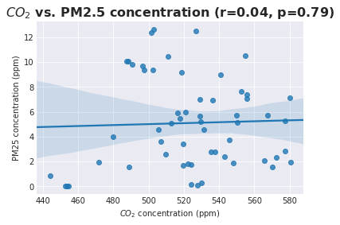

```python
sns.regplot('co2', 'pm25', data=good_data)
plt.xlabel('$CO_2$ concentration (ppm)')
plt.ylabel('PM25 concentration (ppm)')
r, p = pearsonr(good_data['co2'], good_data['pm25'])
plt.title(f'$CO_2$ vs. PM2.5 concentration (r={r:.2f}, p={p:.2f})')
None
```

Whoa. There is *NO* correlation between $CO_2$ concentration at Campolindo and particulate matter concentrations at Miramonte. This indicates that either

- Moraga and Orinda were not affected by the fire similarly, or
- Moraga and Orinda were not affected by the fire at all.

## Getting WeatherUnderground Data

Now let's get data from WeatherUnderground and see if there is any correlations between wind direction and particulate matter or $CO_2$. We might see one of the two pairs being correlated if Moraga and Orinda were affected differently by the fires.

```python
print(f'Getting data from {start} to {end}, from {MORAGA_LOC_ID}.')
moraga_ws = wsu.get_ws_data_by_time(start, end, MORAGA_LOC_ID)

# first, save the DataFrame as a `.csv` file
# before saving, we need to rename the column `Time` to `deviceTime_unix`
header = moraga_ws.columns.values.tolist()
header[6] = 'deviceTime_unix'
print(header)

# comment out this line because we don't want to save the `.csv` file every time we rerun the notebook
moraga_ws.to_csv('wunderground_data/data_fire_chs.csv', na_rep='nan', index=False, header=header)

moraga_ws
```

```
Getting data from 2018-07-01 to 2018-07-08, from KCAMORAG34.
['Dewpoint', 'HourlyPrecipIn', 'Humidity', 'Pressure', 'SolarRadiationWatts/m^2', 'Temperature', 'deviceTime_unix', 'WindDirection', 'WindDirectionDegrees', 'WindSpeedGustMPH', 'WindSpeedMPH', 'dailyrainin']
```

|  | Dewpoint | HourlyPrecipIn | Humidity | Pressure | SolarRadiationWatts/m^2 | Temperature | Time | WindDirection | WindDirectionDegrees | WindSpeedGustMPH | WindSpeedMPH | dailyrainin |
| --- | --- | --- | --- | --- | --- | --- | --- | --- | --- | --- | --- | --- |
| 0 | 10.722222 | 0.0 | 62.0 | 1006.769377 | 0.0 | 18.111111 | 1530428693 | South | 180.0 | 1.1 | 0.7 | 0.0 |
| 1 | 10.888889 | 0.0 | 63.0 | 1006.769377 | 0.0 | 18.000000 | 1530428979 | South | 180.0 | 1.1 | 0.4 | 0.0 |
| 2 | 10.777778 | 0.0 | 63.0 | 1007.108014 | 0.0 | 17.888889 | 1530429289 | South | 180.0 | 1.1 | 0.2 | 0.0 |
| 3 | 10.888889 | 0.0 | 64.0 | 1007.108014 | 0.0 | 17.777778 | 1530429593 | South | 180.0 | 0.0 | 0.0 | 0.0 |
| 4 | 11.111111 | 0.0 | 65.0 | 1007.108014 | 0.0 | 17.722222 | 1530429893 | South | 180.0 | 1.1 | 1.1 | 0.0 |
| 5 | 11.222222 | 0.0 | 66.0 | 1006.769377 | 0.0 | 17.611111 | 1530430179 | South | 180.0 | 1.1 | 0.2 | 0.0 |
| 6 | 11.222222 | 0.0 | 66.0 | 1006.769377 | 0.0 | 17.611111 | 1530430489 | South | 180.0 | 1.1 | 0.9 | 0.0 |
| 7 | 11.388889 | 0.0 | 67.0 | 1006.769377 | 0.0 | 17.611111 | 1530430793 | South | 180.0 | 1.1 | 0.9 | 0.0 |
| 8 | 11.388889 | 0.0 | 67.0 | 1006.769377 | 0.0 | 17.611111 | 1530431093 | South | 180.0 | 1.1 | 0.2 | 0.0 |
| 9 | 11.500000 | 0.0 | 68.0 | 1007.108014 | 0.0 | 17.500000 | 1530431379 | South | 180.0 | 1.1 | 0.2 | 0.0 |
| 10 | 11.722222 | 0.0 | 69.0 | 1007.108014 | 0.0 | 17.388889 | 1530431689 | South | 180.0 | 1.1 | 0.9 | 0.0 |
| 11 | 11.777778 | 0.0 | 70.0 | 1006.769377 | 0.0 | 17.277778 | 1530431993 | South | 180.0 | 1.1 | 0.2 | 0.0 |
| 12 | 11.777778 | 0.0 | 70.0 | 1007.108014 | 0.0 | 17.277778 | 1530432293 | South | 180.0 | 0.0 | 0.0 | 0.0 |
| 13 | 11.888889 | 0.0 | 71.0 | 1006.769377 | 0.0 | 17.222222 | 1530432579 | South | 180.0 | 1.1 | 0.2 | 0.0 |
| 14 | 12.000000 | 0.0 | 72.0 | 1007.108014 | 0.0 | 17.111111 | 1530432889 | South | 180.0 | 0.0 | 0.0 | 0.0 |
| 15 | 12.000000 | 0.0 | 72.0 | 1006.769377 | 0.0 | 17.111111 | 1530433193 | South | 180.0 | 0.0 | 0.0 | 0.0 |
| 16 | 11.888889 | 0.0 | 72.0 | 1006.769377 | 0.0 | 17.000000 | 1530433493 | South | 180.0 | 0.0 | 0.0 | 0.0 |
| 17 | 12.111111 | 0.0 | 73.0 | 1006.769377 | 0.0 | 17.000000 | 1530433779 | South | 180.0 | 1.1 | 0.9 | 0.0 |
| 18 | 12.277778 | 0.0 | 74.0 | 1006.769377 | 0.0 | 16.888889 | 1530434089 | South | 180.0 | 0.0 | 0.0 | 0.0 |
| 19 | 12.277778 | 0.0 | 75.0 | 1006.769377 | 0.0 | 16.722222 | 1530434393 | South | 180.0 | 1.1 | 0.2 | 0.0 |
| 20 | 12.222222 | 0.0 | 75.0 | 1006.769377 | 0.0 | 16.611111 | 1530434693 | South | 180.0 | 1.1 | 0.4 | 0.0 |
| 21 | 12.277778 | 0.0 | 76.0 | 1006.769377 | 0.0 | 16.611111 | 1530434979 | South | 180.0 | 1.1 | 1.1 | 0.0 |
| 22 | 12.277778 | 0.0 | 77.0 | 1006.769377 | 0.0 | 16.388889 | 1530435289 | South | 180.0 | 1.1 | 0.9 | 0.0 |
| 23 | 12.277778 | 0.0 | 77.0 | 1006.769377 | 0.0 | 16.388889 | 1530435593 | South | 180.0 | 1.1 | 0.9 | 0.0 |
| 24 | 12.222222 | 0.0 | 77.0 | 1006.430739 | 0.0 | 16.277778 | 1530435893 | South | 180.0 | 0.0 | 0.0 | 0.0 |
| 25 | 12.388889 | 0.0 | 78.0 | 1006.430739 | 0.0 | 16.222222 | 1530436179 | South | 180.0 | 1.1 | 0.4 | 0.0 |
| 26 | 12.388889 | 0.0 | 78.0 | 1006.430739 | 0.0 | 16.222222 | 1530436489 | South | 180.0 | 1.1 | 0.7 | 0.0 |
| 27 | 12.500000 | 0.0 | 78.0 | 1006.769377 | 0.0 | 16.277778 | 1530436793 | South | 180.0 | 1.1 | 0.2 | 0.0 |
| 28 | 12.500000 | 0.0 | 78.0 | 1006.769377 | 0.0 | 16.277778 | 1530437093 | South | 180.0 | 1.1 | 1.1 | 0.0 |
| 29 | 12.500000 | 0.0 | 78.0 | 1006.430739 | 0.0 | 16.277778 | 1530437379 | South | 180.0 | 1.1 | 1.1 | 0.0 |
| ... | ... | ... | ... | ... | ... | ... | ... | ... | ... | ... | ... | ... |
| 1986 | 11.277778 | 0.0 | 65.0 | 1008.801202 | 0.0 | 18.000000 | 1531024496 | SW | 224.0 | 1.1 | 1.1 | 0.0 |
| 1987 | 11.500000 | 0.0 | 66.0 | 1008.801202 | 0.0 | 17.888889 | 1531024793 | SW | 218.0 | 1.1 | 0.9 | 0.0 |
| 1988 | 11.388889 | 0.0 | 66.0 | 1008.462564 | 0.0 | 17.777778 | 1531025088 | WSW | 238.0 | 2.2 | 1.8 | 0.0 |
| 1989 | 11.388889 | 0.0 | 67.0 | 1008.801202 | 0.0 | 17.611111 | 1531025392 | WSW | 242.0 | 2.2 | 2.2 | 0.0 |
| 1990 | 11.500000 | 0.0 | 68.0 | 1008.801202 | 0.0 | 17.500000 | 1531025681 | SW | 232.0 | 1.1 | 0.9 | 0.0 |
| 1991 | 11.388889 | 0.0 | 68.0 | 1008.801202 | 0.0 | 17.388889 | 1531025993 | WSW | 246.0 | 1.1 | 1.1 | 0.0 |
| 1992 | 11.611111 | 0.0 | 69.0 | 1008.801202 | 0.0 | 17.277778 | 1531026288 | SW | 220.0 | 1.1 | 0.9 | 0.0 |
| 1993 | 11.500000 | 0.0 | 69.0 | 1008.462564 | 0.0 | 17.222222 | 1531026592 | SW | 229.0 | 2.2 | 1.3 | 0.0 |
| 1994 | 11.611111 | 0.0 | 70.0 | 1008.801202 | 0.0 | 17.111111 | 1531026881 | WSW | 241.0 | 2.2 | 0.9 | 0.0 |
| 1995 | 11.722222 | 0.0 | 71.0 | 1009.139839 | 0.0 | 17.000000 | 1531027193 | SW | 227.0 | 2.2 | 1.3 | 0.0 |
| 1996 | 11.722222 | 0.0 | 72.0 | 1008.801202 | 0.0 | 16.777778 | 1531027488 | SSE | 156.0 | 1.1 | 0.7 | 0.0 |
| 1997 | 11.777778 | 0.0 | 73.0 | 1008.801202 | 0.0 | 16.722222 | 1531027792 | SW | 230.0 | 1.1 | 0.2 | 0.0 |
| 1998 | 11.777778 | 0.0 | 73.0 | 1009.139839 | 0.0 | 16.611111 | 1531028081 | WSW | 254.0 | 2.2 | 1.8 | 0.0 |
| 1999 | 11.888889 | 0.0 | 74.0 | 1009.139839 | 0.0 | 16.500000 | 1531028393 | WSW | 252.0 | 1.1 | 0.9 | 0.0 |
| 2000 | 11.777778 | 0.0 | 74.0 | 1009.139839 | 0.0 | 16.388889 | 1531028688 | SW | 231.0 | 2.2 | 1.8 | 0.0 |
| 2001 | 11.888889 | 0.0 | 75.0 | 1009.139839 | 0.0 | 16.277778 | 1531028992 | SW | 230.0 | 1.1 | 1.1 | 0.0 |
| 2002 | 11.777778 | 0.0 | 75.0 | 1009.139839 | 0.0 | 16.222222 | 1531029281 | SW | 234.0 | 2.2 | 1.8 | 0.0 |
| 2003 | 11.611111 | 0.0 | 75.0 | 1009.139839 | 0.0 | 16.000000 | 1531029593 | WSW | 237.0 | 1.1 | 0.9 | 0.0 |
| 2004 | 11.611111 | 0.0 | 75.0 | 1008.801202 | 0.0 | 16.000000 | 1531029888 | WSW | 246.0 | 2.2 | 2.2 | 0.0 |
| 2005 | 11.777778 | 0.0 | 76.0 | 1009.139839 | 0.0 | 16.000000 | 1531030192 | SW | 233.0 | 3.4 | 3.1 | 0.0 |
| 2006 | 11.888889 | 0.0 | 77.0 | 1009.139839 | 0.0 | 15.888889 | 1531030496 | SW | 234.0 | 2.2 | 1.6 | 0.0 |
| 2007 | 11.722222 | 0.0 | 77.0 | 1009.139839 | 0.0 | 15.722222 | 1531030793 | WSW | 239.0 | 2.2 | 2.2 | 0.0 |
| 2008 | 11.777778 | 0.0 | 78.0 | 1009.139839 | 0.0 | 15.611111 | 1531031088 | SW | 236.0 | 2.2 | 1.8 | 0.0 |
| 2009 | 11.722222 | 0.0 | 78.0 | 1009.139839 | 0.0 | 15.500000 | 1531031392 | WSW | 241.0 | 1.1 | 0.4 | 0.0 |
| 2010 | 11.777778 | 0.0 | 79.0 | 1009.139839 | 0.0 | 15.388889 | 1531031681 | SW | 232.0 | 2.2 | 1.1 | 0.0 |
| 2011 | 11.777778 | 0.0 | 79.0 | 1008.801202 | 0.0 | 15.388889 | 1531031993 | WSW | 238.0 | 2.2 | 2.2 | 0.0 |
| 2012 | 11.722222 | 0.0 | 79.0 | 1008.801202 | 0.0 | 15.277778 | 1531032288 | SW | 231.0 | 2.2 | 1.8 | 0.0 |
| 2013 | 11.888889 | 0.0 | 80.0 | 1008.801202 | 0.0 | 15.277778 | 1531032592 | SW | 232.0 | 3.4 | 2.2 | 0.0 |
| 2014 | 11.888889 | 0.0 | 80.0 | 1008.801202 | 0.0 | 15.277778 | 1531032881 | WSW | 246.0 | 2.2 | 2.2 | 0.0 |
| 2015 | 12.000000 | 0.0 | 81.0 | 1008.801202 | 0.0 | 15.222222 | 1531033193 | SW | 220.0 | 3.4 | 2.0 | 0.0 |

2016 rows × 12 columns

```python
print(f'Getting data from {start} to {end}, from {ORINDA_LOC_ID}.')
orinda_ws = wsu.get_ws_data_by_time(start, end, ORINDA_LOC_ID)

# first, save the DataFrame as a `.csv` file
# before saving, we need to rename the column `Time` to `deviceTime_unix`
header = orinda_ws.columns.values.tolist()
header[5] = 'deviceTime_unix'
print(header)

# comment out this line because we don't want to save the `.csv` file every time we rerun the notebook
# orinda_ws.to_csv('wunderground_data/data_fire_mira.csv', na_rep='nan', index=False, header=header)

orinda_ws
```

```
Getting data from 2018-07-01 to 2018-07-08, from KCAORIND23.
['Dewpoint', 'HourlyPrecipIn', 'Humidity', 'Pressure', 'Temperature', 'deviceTime_unix', 'WindDirection', 'WindDirectionDegrees', 'WindSpeedGustMPH', 'WindSpeedMPH', 'dailyrainin']
```

|  | Dewpoint | HourlyPrecipIn | Humidity | Pressure | Temperature | Time | WindDirection | WindDirectionDegrees | WindSpeedGustMPH | WindSpeedMPH | dailyrainin |
| --- | --- | --- | --- | --- | --- | --- | --- | --- | --- | --- | --- |
| 0 | 11.666667 | 0.0 | 83.0 | 1012.864852 | 14.666667 | 1530428822 | WSW | 245.0 | 1.0 | 0.0 | 0.0 |
| 1 | 12.222222 | 0.0 | 85.0 | 1012.864852 | 14.500000 | 1530429724 | WSW | 245.0 | 0.0 | 0.0 | 0.0 |
| 2 | 12.222222 | 0.0 | 86.0 | 1012.864852 | 14.277778 | 1530430626 | WSW | 245.0 | 0.0 | 0.0 | 0.0 |
| 3 | 12.222222 | 0.0 | 87.0 | 1012.864852 | 14.166667 | 1530431527 | WSW | 245.0 | 0.0 | 0.0 | 0.0 |
| 4 | 12.222222 | 0.0 | 87.0 | 1012.864852 | 14.111111 | 1530432428 | WSW | 245.0 | 1.0 | 0.0 | 0.0 |
| 5 | 12.222222 | 0.0 | 88.0 | 1012.864852 | 14.000000 | 1530433329 | WSW | 245.0 | 1.0 | 0.0 | 0.0 |
| 6 | 12.222222 | 0.0 | 89.0 | 1012.864852 | 13.888889 | 1530434230 | WSW | 249.0 | 0.0 | 0.0 | 0.0 |
| 7 | 12.222222 | 0.0 | 89.0 | 1012.526215 | 13.777778 | 1530435133 | WSW | 249.0 | 0.0 | 0.0 | 0.0 |
| 8 | 11.666667 | 0.0 | 89.0 | 1012.526215 | 13.611111 | 1530436035 | WSW | 248.0 | 1.0 | 0.0 | 0.0 |
| 9 | 12.222222 | 0.0 | 90.0 | 1012.526215 | 13.500000 | 1530436936 | WSW | 249.0 | 0.0 | 0.0 | 0.0 |
| 10 | 12.222222 | 0.0 | 91.0 | 1012.526215 | 13.444444 | 1530437837 | WSW | 249.0 | 1.0 | 0.0 | 0.0 |
| 11 | 12.222222 | 0.0 | 91.0 | 1012.526215 | 13.388889 | 1530438739 | WSW | 249.0 | 0.0 | 0.0 | 0.0 |
| 12 | 11.666667 | 0.0 | 91.0 | 1012.864852 | 13.277778 | 1530439639 | WSW | 249.0 | 0.0 | 0.0 | 0.0 |
| 13 | 11.666667 | 0.0 | 91.0 | 1012.864852 | 13.222222 | 1530440540 | WSW | 249.0 | 1.0 | 0.0 | 0.0 |
| 14 | 11.666667 | 0.0 | 91.0 | 1012.864852 | 13.000000 | 1530441441 | WSW | 249.0 | 0.0 | 0.0 | 0.0 |
| 15 | 11.666667 | 0.0 | 92.0 | 1012.864852 | 12.944444 | 1530442343 | WSW | 249.0 | 0.0 | 0.0 | 0.0 |
| 16 | 11.666667 | 0.0 | 92.0 | 1012.864852 | 12.777778 | 1530443244 | WSW | 249.0 | 0.0 | 0.0 | 0.0 |
| 17 | 11.666667 | 0.0 | 92.0 | 1012.864852 | 12.833333 | 1530444145 | WSW | 249.0 | 0.0 | 0.0 | 0.0 |
| 18 | 11.666667 | 0.0 | 92.0 | 1013.203490 | 12.722222 | 1530445047 | WSW | 248.0 | 0.0 | 0.0 | 0.0 |
| 19 | 11.666667 | 0.0 | 93.0 | 1012.864852 | 12.611111 | 1530445948 | WSW | 249.0 | 1.0 | 0.0 | 0.0 |
| 20 | 11.111111 | 0.0 | 92.0 | 1013.203490 | 12.500000 | 1530446849 | WSW | 249.0 | 0.0 | 0.0 | 0.0 |
| 21 | 11.111111 | 0.0 | 93.0 | 1013.203490 | 12.333333 | 1530447751 | WSW | 249.0 | 0.0 | 0.0 | 0.0 |
| 22 | 11.111111 | 0.0 | 93.0 | 1013.542127 | 12.333333 | 1530448653 | WSW | 249.0 | 0.0 | 0.0 | 0.0 |
| 23 | 11.111111 | 0.0 | 93.0 | 1013.542127 | 12.333333 | 1530449555 | WSW | 249.0 | 0.0 | 0.0 | 0.0 |
| 24 | 11.111111 | 0.0 | 93.0 | 1013.880765 | 12.388889 | 1530450457 | WSW | 249.0 | 0.0 | 0.0 | 0.0 |
| 25 | 11.111111 | 0.0 | 93.0 | 1013.880765 | 12.388889 | 1530451358 | WSW | 249.0 | 1.0 | 0.0 | 0.0 |
| 26 | 11.666667 | 0.0 | 94.0 | 1013.880765 | 12.611111 | 1530452259 | West | 271.0 | 2.0 | 0.0 | 0.0 |
| 27 | 11.666667 | 0.0 | 94.0 | 1014.219402 | 12.777778 | 1530453160 | SW | 233.0 | 2.0 | 0.0 | 0.0 |
| 28 | 12.222222 | 0.0 | 94.0 | 1014.219402 | 13.000000 | 1530454063 | SW | 234.0 | 0.0 | 0.0 | 0.0 |
| 29 | 12.777778 | 0.0 | 94.0 | 1014.558040 | 13.555556 | 1530454964 | SW | 233.0 | 1.0 | 0.0 | 0.0 |
| ... | ... | ... | ... | ... | ... | ... | ... | ... | ... | ... | ... |
| 641 | 9.444444 | 0.0 | 26.0 | 1014.558040 | 31.000000 | 1531006746 | SSW | 207.0 | 8.0 | 2.0 | 0.0 |
| 642 | 9.444444 | 0.0 | 27.0 | 1014.219402 | 30.555556 | 1531007648 | SW | 230.0 | 8.0 | 4.0 | 0.0 |
| 643 | 10.000000 | 0.0 | 30.0 | 1014.219402 | 29.555556 | 1531008549 | SW | 221.0 | 9.0 | 4.0 | 0.0 |
| 644 | 10.555556 | 0.0 | 31.0 | 1014.219402 | 29.333333 | 1531009509 | SW | 227.0 | 10.0 | 1.0 | 0.0 |
| 645 | 10.000000 | 0.0 | 30.0 | 1013.880765 | 29.111111 | 1531010351 | SSW | 196.0 | 7.0 | 1.0 | 0.0 |
| 646 | 10.555556 | 0.0 | 32.0 | 1013.880765 | 28.833333 | 1531011252 | WSW | 247.0 | 6.0 | 3.0 | 0.0 |
| 647 | 10.555556 | 0.0 | 32.0 | 1013.880765 | 28.777778 | 1531012155 | WSW | 245.0 | 9.0 | 1.0 | 0.0 |
| 648 | 11.111111 | 0.0 | 34.0 | 1013.880765 | 28.666667 | 1531013055 | SSW | 207.0 | 6.0 | 2.0 | 0.0 |
| 649 | 11.111111 | 0.0 | 35.0 | 1013.880765 | 28.222222 | 1531013956 | SSE | 155.0 | 5.0 | 4.0 | 0.0 |
| 650 | 11.111111 | 0.0 | 37.0 | 1013.880765 | 27.111111 | 1531014857 | SSW | 203.0 | 5.0 | 2.0 | 0.0 |
| 651 | 11.666667 | 0.0 | 40.0 | 1013.542127 | 26.333333 | 1531015757 | West | 260.0 | 5.0 | 0.0 | 0.0 |
| 652 | 12.222222 | 0.0 | 43.0 | 1013.542127 | 25.611111 | 1531016659 | SSW | 213.0 | 5.0 | 2.0 | 0.0 |
| 653 | 11.666667 | 0.0 | 44.0 | 1013.542127 | 24.611111 | 1531017559 | SSW | 210.0 | 7.0 | 0.0 | 0.0 |
| 654 | 11.666667 | 0.0 | 47.0 | 1013.542127 | 23.833333 | 1531018460 | SSE | 164.0 | 6.0 | 1.0 | 0.0 |
| 655 | 11.111111 | 0.0 | 47.0 | 1013.542127 | 23.333333 | 1531019362 | SE | 124.0 | 5.0 | 3.0 | 0.0 |
| 656 | 9.444444 | 0.0 | 42.0 | 1013.542127 | 23.055556 | 1531020264 | SW | 225.0 | 5.0 | 1.0 | 0.0 |
| 657 | 9.444444 | 0.0 | 42.0 | 1013.880765 | 23.055556 | 1531021165 | South | 169.0 | 5.0 | 0.0 | 0.0 |
| 658 | 10.000000 | 0.0 | 44.0 | 1013.880765 | 22.722222 | 1531022065 | SE | 146.0 | 7.0 | 2.0 | 0.0 |
| 659 | 10.555556 | 0.0 | 49.0 | 1013.880765 | 21.944444 | 1531022966 | SSE | 164.0 | 4.0 | 0.0 | 0.0 |
| 660 | 11.111111 | 0.0 | 52.0 | 1013.880765 | 21.277778 | 1531023867 | SSE | 163.0 | 4.0 | 0.0 | 0.0 |
| 661 | 11.111111 | 0.0 | 53.0 | 1013.880765 | 20.888889 | 1531024767 | SSE | 162.0 | 4.0 | 3.0 | 0.0 |
| 662 | 10.555556 | 0.0 | 55.0 | 1014.219402 | 20.222222 | 1531025667 | SSE | 151.0 | 5.0 | 3.0 | 0.0 |
| 663 | 10.000000 | 0.0 | 53.0 | 1013.880765 | 20.000000 | 1531026567 | SE | 124.0 | 4.0 | 2.0 | 0.0 |
| 664 | 10.555556 | 0.0 | 57.0 | 1014.219402 | 19.444444 | 1531027469 | SE | 141.0 | 4.0 | 3.0 | 0.0 |
| 665 | 10.555556 | 0.0 | 59.0 | 1014.219402 | 18.888889 | 1531028369 | ESE | 117.0 | 4.0 | 1.0 | 0.0 |
| 666 | 10.555556 | 0.0 | 62.0 | 1014.219402 | 18.222222 | 1531029270 | SE | 143.0 | 5.0 | 4.0 | 0.0 |
| 667 | 10.555556 | 0.0 | 64.0 | 1014.558040 | 17.777778 | 1531030171 | SE | 139.0 | 7.0 | 7.0 | 0.0 |
| 668 | 11.111111 | 0.0 | 66.0 | 1014.219402 | 17.333333 | 1531031071 | SSE | 147.0 | 7.0 | 2.0 | 0.0 |
| 669 | 10.555556 | 0.0 | 66.0 | 1014.558040 | 17.222222 | 1531031971 | ESE | 123.0 | 5.0 | 3.0 | 0.0 |
| 670 | 11.111111 | 0.0 | 67.0 | 1014.219402 | 17.111111 | 1531032872 | SSE | 148.0 | 4.0 | 2.0 | 0.0 |

671 rows × 11 columns

```python
winddir_data_interval = pd.read_csv(f'binned_data_10_days/ws_chs_data_WindDirectionDegrees_{INTERVAL}.csv',
                                header=0, names=['unix_time', 'WindDirection'], usecols=[1])
windspd_data_interval = pd.read_csv(f'binned_data_10_days/ws_chs_data_WindSpeedGustMPH_{INTERVAL}.csv',
                                header=0, names=['unix_time', 'WindSpeedGustMPH'], usecols=[1])
temp_data_interval = pd.read_csv(f'binned_data_10_days/ws_chs_data_Temperature_{INTERVAL}.csv',
                                header=0, names=['unix_time', 'Temperature'], usecols=[1])
pressure_data_interval = pd.read_csv(f'binned_data_10_days/ws_chs_data_Pressure_{INTERVAL}.csv',
                                header=0, names=['unix_time', 'Pressure'], usecols=[1])
humidity_data_interval = pd.read_csv(f'binned_data_10_days/ws_chs_data_Humidity_{INTERVAL}.csv',
                                header=0, names=['unix_time', 'Humidity'], usecols=[1])
moraga_dosenet_and_ws = pd.concat([moraga_data, winddir_data_interval, windspd_data_interval,
                                   temp_data_interval, pressure_data_interval, humidity_data_interval],
                                  axis=1)
moraga_dosenet_and_ws.dropna(axis=0, how='any', inplace=True)  # there are some NaNs
moraga_dosenet_and_ws
```

|  | unix_time | co2 | radiation | pgradiation | humidity | temperature | pressure | WindDirection | WindSpeedGustMPH | Temperature | Pressure | Humidity |
| --- | --- | --- | --- | --- | --- | --- | --- | --- | --- | --- | --- | --- |
| 21 | 1.530482e+09 | 545.979130 | 1227.121739 | 1.725000 | 60.487391 | 21.732609 | 993.027391 | 213.166667 | 3.163889 | 18.387346 | 1009.262125 | 73.583333 |
| 22 | 1.530493e+09 | 535.310000 | 1219.511111 | 1.811111 | 71.637500 | 18.208611 | 992.914722 | 216.277778 | 2.463889 | 15.305556 | 1008.942301 | 85.083333 |
| 23 | 1.530504e+09 | 519.441667 | 1226.455556 | 1.822222 | 82.555556 | 15.506389 | 993.012222 | 196.777778 | 2.119444 | 13.438272 | 1008.810608 | 93.277778 |
| 24 | 1.530515e+09 | 531.253611 | 1233.475676 | 1.972222 | 86.050000 | 15.102778 | 992.399167 | 184.027778 | 1.202778 | 13.328704 | 1008.208586 | 95.083333 |
| 25 | 1.530526e+09 | 529.483333 | 1231.254054 | 1.805556 | 86.677778 | 14.675278 | 992.145556 | 203.694444 | 0.961111 | 13.245370 | 1007.879355 | 94.888889 |
| 26 | 1.530536e+09 | 529.158378 | 1220.940541 | 1.844444 | 81.995135 | 15.376757 | 992.812973 | 178.416667 | 1.619444 | 13.898148 | 1008.424938 | 90.305556 |
| 27 | 1.530547e+09 | 550.115833 | 1209.083333 | 1.832432 | 67.947222 | 19.282222 | 992.770833 | 193.333333 | 2.952778 | 18.422840 | 1008.462564 | 73.305556 |
| 28 | 1.530558e+09 | 555.925833 | 1219.448649 | 1.902703 | 58.695833 | 21.875833 | 992.509167 | 231.416667 | 3.647222 | 20.356481 | 1008.293246 | 65.555556 |
| 29 | 1.530569e+09 | 536.211111 | 1228.955556 | 1.740541 | 59.525278 | 21.464444 | 991.152500 | 230.305556 | 3.133333 | 19.597222 | 1007.004542 | 67.583333 |
| 30 | 1.530580e+09 | 519.572500 | 1222.433333 | 1.638889 | 71.645000 | 17.783333 | 989.976389 | 208.305556 | 2.144444 | 16.285494 | 1005.715838 | 79.444444 |
| 31 | 1.530590e+09 | 509.641081 | 1228.205556 | 1.816667 | 83.009444 | 14.836111 | 989.793056 | 178.583333 | 1.933333 | 13.086420 | 1005.537112 | 92.138889 |
| 32 | 1.530601e+09 | 507.086667 | 1232.583333 | 1.972973 | 87.177500 | 14.156944 | 988.838056 | 202.833333 | 1.386111 | 12.793210 | 1004.474167 | 95.027778 |
| 33 | 1.530612e+09 | 512.673243 | 1234.316667 | 1.740541 | 88.553611 | 14.389722 | 988.175000 | 207.166667 | 1.763889 | 13.717593 | 1003.825111 | 92.250000 |
| 34 | 1.530623e+09 | 517.718056 | 1227.237838 | 1.697297 | 84.409189 | 14.767838 | 989.187027 | 194.527778 | 2.830556 | 14.165123 | 1004.765771 | 88.333333 |
| 35 | 1.530634e+09 | 550.240556 | 1219.661538 | 1.788889 | 66.844722 | 18.959444 | 989.925833 | 179.777778 | 4.783333 | 18.452160 | 1005.499486 | 69.166667 |
| 36 | 1.530644e+09 | 580.090278 | 1228.044444 | 1.716667 | 50.250278 | 23.548611 | 989.689444 | 195.083333 | 4.013889 | 22.819444 | 1005.358387 | 52.583333 |
| 37 | 1.530655e+09 | 555.103514 | 1219.816667 | 1.724324 | 51.957778 | 23.038889 | 989.366111 | 239.833333 | 3.744444 | 20.066358 | 1005.142035 | 61.555556 |
| 38 | 1.530666e+09 | 526.770000 | 1220.427778 | 1.750000 | 66.444722 | 18.326111 | 989.364167 | 206.888889 | 2.661111 | 15.427469 | 1005.151442 | 76.861111 |
| 39 | 1.530677e+09 | 501.408108 | 1218.050000 | 1.756757 | 75.716757 | 15.374865 | 990.101892 | 186.222222 | 0.644444 | 13.012346 | 1005.791090 | 87.000000 |
| 40 | 1.530688e+09 | 502.717027 | 1226.744444 | 1.927778 | 80.391081 | 14.459189 | 990.421622 | 212.083333 | 0.458333 | 12.174383 | 1005.969816 | 91.777778 |
| 41 | 1.530698e+09 | 510.852632 | 1232.421622 | 1.600000 | 81.232973 | 14.309459 | 990.865946 | 195.027778 | 0.488889 | 12.390432 | 1006.458959 | 91.166667 |
| 42 | 1.530709e+09 | 497.568889 | 1230.545946 | 1.944444 | 78.657222 | 14.710278 | 992.620278 | 208.638889 | 1.875000 | 13.774691 | 1008.208586 | 83.972222 |
| 43 | 1.530720e+09 | 502.244167 | 1230.188889 | 1.681081 | 68.135833 | 17.280278 | 994.071667 | 196.694444 | 2.977778 | 17.141975 | 1009.657202 | 70.944444 |
| 44 | 1.530731e+09 | 518.691892 | 1222.740541 | 1.772973 | 57.617027 | 20.697297 | 994.394324 | 200.444444 | 4.216667 | 20.225309 | 1010.042873 | 61.027778 |
| 45 | 1.530742e+09 | 520.920833 | 1220.811111 | 1.833333 | 56.730556 | 20.899444 | 993.797778 | 236.055556 | 3.538889 | 19.223765 | 1009.534917 | 62.805556 |
| 46 | 1.530752e+09 | 505.820000 | 1218.744444 | 1.816216 | 66.263056 | 17.956111 | 993.815000 | 234.611111 | 1.547222 | 15.660494 | 1009.591356 | 76.083333 |
| 47 | 1.530763e+09 | 487.284865 | 1220.777778 | 1.694737 | 79.236111 | 14.306667 | 995.176667 | 211.750000 | 0.672222 | 12.432099 | 1010.908280 | 88.250000 |
| 48 | 1.530774e+09 | 496.517778 | 1214.022222 | 1.788889 | 84.060000 | 13.425556 | 996.065000 | 180.388889 | 0.861111 | 11.567901 | 1011.651401 | 93.944444 |
| 49 | 1.530785e+09 | 490.826111 | 1222.344444 | 1.751351 | 89.416944 | 13.005000 | 996.451944 | 183.194444 | 1.986111 | 11.808642 | 1012.018258 | 96.027778 |
| 50 | 1.530796e+09 | 488.277222 | 1216.247368 | 1.627778 | 85.241944 | 13.312222 | 997.872778 | 199.277778 | 2.083333 | 12.535494 | 1013.457468 | 90.000000 |
| 51 | 1.530806e+09 | 541.047222 | 1204.995000 | 1.631579 | 64.161579 | 19.797105 | 998.448684 | 166.000000 | 3.577778 | 19.824074 | 1014.021864 | 63.527778 |
| 52 | 1.530817e+09 | 567.509722 | 1214.333333 | 1.772973 | 38.780811 | 26.802432 | 998.511081 | 193.305556 | 2.975000 | 26.328704 | 1014.228809 | 38.583333 |
| 53 | 1.530828e+09 | 488.881389 | 1224.827778 | 2.011111 | 28.254444 | 29.708056 | 997.704722 | 210.500000 | 1.488889 | 28.398148 | 1013.655006 | 25.805556 |
| 54 | 1.530839e+09 | 471.864444 | 1224.450000 | 1.735135 | 42.483333 | 25.617222 | 998.249444 | 198.833333 | 1.016667 | 22.473765 | 1014.322875 | 48.055556 |
| 55 | 1.530850e+09 | 522.414167 | 1220.444444 | 1.811111 | 57.476667 | 20.500000 | 999.459167 | 166.027778 | 0.030556 | 16.867284 | 1015.348194 | 67.138889 |
| 56 | 1.530860e+09 | 524.298056 | 1240.488889 | 1.800000 | 65.748889 | 17.779167 | 999.176667 | 166.000000 | 0.152778 | 15.186728 | 1015.000150 | 76.666667 |
| 57 | 1.530871e+09 | 548.163684 | 1247.844444 | 1.833333 | 66.930556 | 17.663889 | 997.949167 | 165.972222 | 0.091667 | 15.220679 | 1013.749072 | 78.361111 |
| 58 | 1.530882e+09 | 537.873514 | 1234.333333 | 1.905556 | 68.070000 | 18.367500 | 998.834167 | 165.666667 | 0.213889 | 16.930556 | 1014.558040 | 75.805556 |
| 59 | 1.530893e+09 | 577.544474 | 1212.841860 | 1.961111 | 52.708649 | 22.581351 | 998.868919 | 183.194444 | 1.080556 | 21.628086 | 1014.614479 | 60.388889 |
| 60 | 1.530904e+09 | 523.967778 | 1213.015385 | 2.500000 | 30.027778 | 30.175278 | 997.813889 | 240.583333 | 2.580556 | 30.009259 | 1013.626787 | 29.222222 |
| 61 | 1.530914e+09 | 454.529167 | 1221.666667 | 5.550000 | 25.104167 | 32.058056 | 996.211944 | 146.611111 | 2.788889 | 30.742284 | 1012.262830 | 25.888889 |
| 62 | 1.530925e+09 | 452.792778 | 1218.811111 | 2.111111 | 31.816389 | 28.132500 | 995.670556 | 314.388889 | 0.522222 | 25.387346 | 1011.820720 | 36.361111 |
| 63 | 1.530936e+09 | 530.023611 | 1234.138889 | 1.837838 | 53.018889 | 22.591389 | 995.973056 | 337.000000 | 0.030556 | 19.120370 | 1012.084105 | 66.222222 |
| 64 | 1.530947e+09 | 580.558611 | 1249.400000 | 1.872222 | 65.657222 | 19.437500 | 995.365833 | 276.527778 | 0.213889 | 16.108025 | 1011.312764 | 80.194444 |
| 65 | 1.530958e+09 | 570.223611 | 1261.661111 | 1.738889 | 74.313889 | 17.028333 | 995.150556 | 163.527778 | 0.611111 | 13.737654 | 1011.124632 | 88.666667 |
| 66 | 1.530968e+09 | 565.723243 | 1254.050000 | 1.789189 | 66.122703 | 18.739189 | 995.472703 | 165.055556 | 0.672222 | 17.405864 | 1011.293950 | 74.166667 |
| 67 | 1.530979e+09 | 527.586111 | 1231.988889 | 1.750000 | 29.546389 | 27.336944 | 994.991944 | 204.222222 | 2.075000 | 27.850309 | 1010.974126 | 35.861111 |
| 68 | 1.530990e+09 | 453.621389 | 1225.938889 | 5.400000 | 18.980000 | 32.295833 | 994.148333 | 229.777778 | 2.488889 | 30.973765 | 1010.353291 | 21.138889 |
| 69 | 1.531001e+09 | 443.946389 | 1232.283333 | 7.372973 | 19.618889 | 31.941944 | 992.644444 | 215.166667 | 2.716667 | 29.483025 | 1009.036367 | 25.416667 |
| 70 | 1.531012e+09 | 480.025556 | 1222.838889 | 1.844444 | 39.571389 | 26.328333 | 992.015556 | 197.194444 | 2.602778 | 23.365741 | 1008.349685 | 48.416667 |
| 71 | 1.531022e+09 | 516.623333 | 1218.466667 | 1.672222 | 61.243889 | 19.395556 | 992.575556 | 231.277778 | 1.872222 | 16.793210 | 1008.848235 | 71.944444 |

```python
winddir_data_interval = pd.read_csv(f'binned_data_10_days/ws_mira_data_WindDirectionDegrees_{INTERVAL}.csv',
                                header=0, names=['unix_time', 'WindDirection'], usecols=[1])
windspd_data_interval = pd.read_csv(f'binned_data_10_days/ws_mira_data_WindSpeedGustMPH_{INTERVAL}.csv',
                                header=0, names=['unix_time', 'WindSpeedGustMPH'], usecols=[1])
temp_data_interval = pd.read_csv(f'binned_data_10_days/ws_mira_data_Temperature_{INTERVAL}.csv',
                                header=0, names=['unix_time', 'Temperature'], usecols=[1])
pressure_data_interval = pd.read_csv(f'binned_data_10_days/ws_mira_data_Pressure_{INTERVAL}.csv',
                                header=0, names=['unix_time', 'Pressure'], usecols=[1])
humidity_data_interval = pd.read_csv(f'binned_data_10_days/ws_mira_data_Humidity_{INTERVAL}.csv',
                                header=0, names=['unix_time', 'Humidity'], usecols=[1])
orinda_dosenet_and_ws = pd.concat([orinda_data, winddir_data_interval, windspd_data_interval,
                                   temp_data_interval, pressure_data_interval, humidity_data_interval],
                                  axis=1)
orinda_dosenet_and_ws.dropna(axis=0, how='any', inplace=True)  # there are some NaNs
orinda_dosenet_and_ws
```

|  | unix_time | co2 | pgradiation | humidity | temperature | pressure | pm1 | pm25 | pm10 | WindDirection | WindSpeedGustMPH | Temperature | Pressure | Humidity |
| --- | --- | --- | --- | --- | --- | --- | --- | --- | --- | --- | --- | --- | --- | --- |
| 16 | 1.530428e+09 | 0.0 | 1.877778 | 59.031944 | 20.168611 | 995.142500 | 3.292500 | 5.631389 | 8.031944 | 246.916667 | 0.416667 | 13.944444 | 1012.723753 | 87.916667 |
| 17 | 1.530439e+09 | 0.0 | 1.938889 | 66.530278 | 18.967222 | 995.550278 | 4.058611 | 6.575833 | 9.204444 | 248.916667 | 0.166667 | 12.740741 | 1013.062391 | 92.083333 |
| 18 | 1.530450e+09 | 0.0 | 1.983333 | 68.019444 | 20.024722 | 996.865556 | 4.419167 | 7.218611 | 9.882500 | 222.000000 | 1.083333 | 14.402778 | 1014.332282 | 91.416667 |
| 19 | 1.530461e+09 | 0.0 | 1.977778 | 57.597222 | 23.603333 | 996.960278 | 4.697222 | 7.280556 | 9.547778 | 269.833333 | 2.166667 | 22.273148 | 1014.670919 | 65.083333 |
| 20 | 1.530472e+09 | 0.0 | 1.866667 | 58.605833 | 22.644444 | 997.405556 | 2.664444 | 4.659167 | 6.218056 | 207.833333 | 8.166667 | 21.000000 | 1014.953117 | 63.833333 |
| 21 | 1.530482e+09 | 0.0 | 1.982857 | 68.426857 | 19.852857 | 997.686000 | 1.842571 | 3.759429 | 5.328286 | 208.916667 | 10.500000 | 18.611111 | 1014.953117 | 72.416667 |
| 22 | 1.530493e+09 | 0.0 | 1.962162 | 69.224167 | 19.094444 | 997.418056 | 1.298889 | 2.796389 | 3.939444 | 202.750000 | 6.583333 | 16.467593 | 1014.783798 | 78.750000 |
| 23 | 1.530504e+09 | 0.0 | 1.816667 | 75.328611 | 17.256111 | 997.418889 | 0.596389 | 1.674444 | 2.581111 | 179.500000 | 5.000000 | 14.000000 | 1014.783798 | 88.916667 |
| 24 | 1.530515e+09 | 0.0 | 1.872222 | 78.278056 | 16.781111 | 996.766111 | 2.456389 | 4.570556 | 6.392778 | 177.416667 | 1.333333 | 13.425926 | 1014.332282 | 92.000000 |
| 25 | 1.530526e+09 | 0.0 | 1.872222 | 80.548889 | 16.038333 | 996.465833 | 3.040000 | 5.214444 | 7.325556 | 167.250000 | 0.583333 | 12.939815 | 1014.021864 | 92.250000 |
| 26 | 1.530536e+09 | 0.0 | 1.966667 | 77.472432 | 16.461622 | 997.076216 | 3.604324 | 5.655135 | 7.619189 | 143.833333 | 1.083333 | 13.550926 | 1014.755578 | 92.166667 |
| 27 | 1.530547e+09 | 0.0 | 1.733333 | 72.545556 | 18.173056 | 997.151111 | 3.595556 | 5.704167 | 7.631111 | 190.500000 | 7.333333 | 17.273148 | 1014.727359 | 77.666667 |
| 28 | 1.530558e+09 | 0.0 | 1.783333 | 68.128889 | 19.631389 | 997.023056 | 4.502778 | 7.081111 | 9.529722 | 193.666667 | 10.750000 | 18.638889 | 1014.501600 | 72.000000 |
| 29 | 1.530569e+09 | 0.0 | 1.844444 | 65.381111 | 20.201389 | 995.710278 | 4.446944 | 6.910556 | 9.342500 | 176.750000 | 8.750000 | 18.708333 | 1012.977731 | 71.250000 |
| 30 | 1.530580e+09 | 0.0 | 1.722222 | 68.250556 | 18.907778 | 994.435556 | 1.663889 | 3.426111 | 4.786389 | 172.666667 | 8.083333 | 15.245370 | 1011.848940 | 83.666667 |
| 31 | 1.530590e+09 | 0.0 | 1.916667 | 76.424722 | 16.393333 | 994.242222 | 1.153889 | 2.590278 | 3.672500 | 162.166667 | 5.166667 | 13.236111 | 1011.651401 | 90.666667 |
| 32 | 1.530601e+09 | 0.0 | 1.927778 | 77.868611 | 16.131944 | 993.228333 | 1.956111 | 3.598056 | 5.094444 | 205.333333 | 4.416667 | 12.967593 | 1010.720148 | 91.583333 |
| 33 | 1.530612e+09 | 0.0 | 1.838889 | 78.228333 | 16.546389 | 992.511667 | 2.901944 | 5.093333 | 7.032778 | 175.916667 | 3.416667 | 13.430556 | 1010.042873 | 91.250000 |
| 34 | 1.530623e+09 | 0.0 | 1.733333 | 75.704722 | 16.701944 | 993.463333 | 3.284722 | 5.464444 | 7.556944 | 194.250000 | 5.166667 | 14.018519 | 1011.030566 | 87.583333 |
| 35 | 1.530634e+09 | 0.0 | 1.877778 | 68.151389 | 18.391389 | 994.219444 | 3.018056 | 5.137500 | 7.309167 | 209.833333 | 7.500000 | 18.365741 | 1011.764280 | 69.500000 |
| 36 | 1.530644e+09 | 0.0 | 1.788889 | 58.030833 | 21.297500 | 994.025000 | 4.160556 | 7.115833 | 10.228056 | 212.000000 | 8.333333 | 21.569444 | 1011.707841 | 57.583333 |
| 37 | 1.530655e+09 | 0.0 | 2.091892 | 59.265556 | 21.029722 | 993.804722 | 6.605833 | 10.531111 | 15.104167 | 220.416667 | 8.500000 | 20.231481 | 1011.482082 | 61.250000 |
| 38 | 1.530666e+09 | 0.0 | 1.833333 | 63.631944 | 18.794167 | 993.778056 | 8.084722 | 12.488889 | 17.899167 | 192.333333 | 7.916667 | 15.583333 | 1011.284544 | 76.250000 |
| 39 | 1.530677e+09 | 0.0 | 1.794595 | 69.683889 | 16.840556 | 994.440556 | 7.957500 | 12.366111 | 17.728333 | 150.833333 | 4.166667 | 13.449074 | 1011.961819 | 84.416667 |
| 40 | 1.530688e+09 | 0.0 | 1.821622 | 72.845135 | 16.249730 | 994.721892 | 8.190833 | 12.644167 | 18.119167 | 149.583333 | 2.250000 | 12.726852 | 1012.187577 | 87.916667 |
| 41 | 1.530698e+09 | 0.0 | 1.870270 | 73.172703 | 16.222703 | 995.127568 | 6.855000 | 10.438421 | 14.791053 | 190.000000 | 1.416667 | 13.217593 | 1012.780193 | 86.666667 |
| 42 | 1.530709e+09 | 0.0 | 1.888889 | 72.187222 | 16.232778 | 996.860556 | 6.334444 | 9.376667 | 13.073889 | 175.666667 | 5.166667 | 13.685185 | 1014.642699 | 83.166667 |
| 43 | 1.530720e+09 | 0.0 | 1.977778 | 67.786944 | 17.506111 | 998.361111 | 6.386944 | 9.371944 | 12.912222 | 193.083333 | 8.750000 | 16.208333 | 1016.194788 | 73.416667 |
| 44 | 1.530731e+09 | 0.0 | 1.897297 | 63.391892 | 19.291622 | 998.759189 | 6.148378 | 9.183784 | 12.727297 | 199.250000 | 9.166667 | 19.722222 | 1016.505206 | 63.083333 |
| 45 | 1.530742e+09 | 0.0 | 1.989189 | 60.308333 | 20.126111 | 998.154444 | 3.704444 | 5.988889 | 8.436667 | 200.363636 | 7.000000 | 19.505051 | 1015.912590 | 63.636364 |
| 46 | 1.530752e+09 | 0.0 | 1.905556 | 60.005556 | 20.012500 | 998.041944 | 2.492778 | 4.537500 | 6.420278 | 187.833333 | 4.916667 | 16.472222 | 1015.827931 | 73.000000 |
| 47 | 1.530763e+09 | 0.0 | 1.875676 | 67.836944 | 17.120278 | 999.457222 | 6.720556 | 10.070833 | 13.906667 | 177.583333 | 5.583333 | 12.865741 | 1017.154261 | 85.833333 |
| 48 | 1.530774e+09 | 0.0 | 1.744444 | 74.408919 | 15.418108 | 1000.324595 | 6.414722 | 9.715556 | 13.295556 | 172.166667 | 5.750000 | 12.027778 | 1018.029075 | 90.000000 |
| 49 | 1.530785e+09 | 0.0 | 1.924324 | 77.546389 | 15.222222 | 1000.740556 | 6.532222 | 9.835833 | 13.616111 | 211.916667 | 4.583333 | 11.578704 | 1018.424152 | 92.333333 |
| 50 | 1.530796e+09 | 0.0 | 1.711111 | 76.203889 | 15.269444 | 1002.170833 | 6.799459 | 10.057027 | 13.839730 | 169.500000 | 3.583333 | 12.263889 | 1019.806922 | 89.500000 |
| 51 | 1.530806e+09 | 0.0 | 1.738889 | 66.818889 | 19.662500 | 1002.577222 | 6.142778 | 8.980556 | 12.249444 | 188.166667 | 3.666667 | 20.953704 | 1020.399537 | 59.750000 |
| 52 | 1.530817e+09 | 0.0 | 1.897297 | 49.243784 | 23.579189 | 1002.816486 | 3.516389 | 5.742778 | 7.813333 | 211.166667 | 7.250000 | 25.513889 | 1020.766395 | 43.916667 |
| 53 | 1.530828e+09 | 0.0 | 2.783333 | 32.327222 | 26.400556 | 1002.015833 | 0.547778 | 1.583333 | 2.425556 | 285.750000 | 4.416667 | 29.560185 | 1020.032680 | 30.416667 |
| 54 | 1.530839e+09 | 0.0 | 3.150000 | 42.799722 | 24.835833 | 1002.560278 | 0.788333 | 1.926389 | 2.888056 | 210.000000 | 6.000000 | 21.833333 | 1020.427757 | 54.583333 |
| 55 | 1.530850e+09 | 0.0 | 1.938889 | 55.698333 | 20.840556 | 1003.681667 | 0.732500 | 1.788611 | 2.718889 | 188.000000 | 0.916667 | 17.393519 | 1021.556549 | 70.500000 |
| 56 | 1.530860e+09 | 0.0 | 1.677778 | 63.460833 | 18.558611 | 1003.438333 | 0.652895 | 1.722105 | 2.638158 | 109.000000 | 0.000000 | 14.805556 | 1021.189692 | 79.250000 |
| 57 | 1.530871e+09 | 0.0 | 1.766667 | 64.831111 | 18.469167 | 1002.171944 | 0.764167 | 1.904167 | 2.802778 | 114.500000 | 0.333333 | 15.226852 | 1019.835141 | 77.166667 |
| 58 | 1.530882e+09 | 0.0 | 1.794595 | 66.294324 | 19.122432 | 1003.077297 | 1.281389 | 2.756111 | 3.812222 | 164.083333 | 0.583333 | 16.916667 | 1020.709955 | 75.000000 |
| 59 | 1.530893e+09 | 0.0 | 1.700000 | 60.401351 | 21.756216 | 1003.078649 | 1.306389 | 2.815000 | 4.075833 | 154.416667 | 1.000000 | 22.199074 | 1020.709955 | 57.333333 |
| 60 | 1.530904e+09 | 0.0 | 2.555556 | 39.238333 | 26.329167 | 1002.075278 | 0.015000 | 0.169167 | 0.291389 | 277.583333 | 3.833333 | 30.476852 | 1019.891581 | 31.250000 |
| 61 | 1.530914e+09 | 0.0 | 9.400000 | 32.241111 | 29.038056 | 1000.415278 | 0.000000 | 0.001944 | 0.002222 | 243.583333 | 5.583333 | 33.027778 | 1018.141954 | 25.416667 |
| 62 | 1.530925e+09 | 0.0 | 3.741176 | 35.531111 | 27.536667 | 999.860278 | 0.001944 | 0.028056 | 0.038889 | 274.833333 | 2.000000 | 27.699074 | 1017.577558 | 34.500000 |
| 63 | 1.530936e+09 | 0.0 | 2.027778 | 50.753611 | 21.941667 | 1000.236389 | 0.004167 | 0.250833 | 0.437222 | 248.000000 | 0.000000 | 19.791667 | 1017.746877 | 56.333333 |
| 64 | 1.530947e+09 | 0.0 | 1.911111 | 62.401667 | 19.217778 | 999.661667 | 0.735676 | 1.932703 | 2.954054 | 131.666667 | 0.166667 | 16.185185 | 1017.126041 | 70.166667 |
| 65 | 1.530958e+09 | 0.0 | 1.827778 | 68.196944 | 17.119444 | 999.438333 | 0.528378 | 1.578108 | 2.500270 | 132.333333 | 0.166667 | 14.064815 | 1016.872063 | 79.166667 |
| 66 | 1.530968e+09 | 0.0 | 1.854054 | 66.680270 | 18.301892 | 999.737838 | 0.851389 | 2.097222 | 3.051389 | 159.333333 | 0.333333 | 16.861111 | 1017.238920 | 74.083333 |
| 67 | 1.530979e+09 | 0.0 | 2.033333 | 43.789444 | 24.178056 | 999.286111 | 0.000000 | 0.083333 | 0.132500 | 259.666667 | 4.250000 | 27.865741 | 1016.956722 | 30.666667 |
| 68 | 1.530990e+09 | 0.0 | 3.483333 | 28.555278 | 27.594722 | 998.632222 | 0.000000 | 0.046944 | 0.073056 | 237.666667 | 3.750000 | 32.541667 | 1016.138348 | 17.833333 |
| 69 | 1.531001e+09 | 0.0 | 11.416667 | 29.474722 | 28.460278 | 997.173333 | 0.138333 | 0.877500 | 1.460000 | 216.833333 | 7.250000 | 30.305556 | 1014.558040 | 28.000000 |
| 70 | 1.531012e+09 | 0.0 | 10.511765 | 39.293333 | 26.898889 | 996.401667 | 1.876389 | 3.994444 | 5.946944 | 193.416667 | 5.833333 | 25.444444 | 1013.711446 | 40.583333 |
| 71 | 1.531022e+09 | 0.0 | 1.944444 | 55.901351 | 21.577027 | 997.150541 | 3.201389 | 5.941389 | 8.578056 | 143.500000 | 4.750000 | 19.194444 | 1014.162963 | 58.583333 |

Now let's see the correlations between $CO_2$ concentration and wind direction in Moraga, with the size of the circles (importance) depending on wind speed.

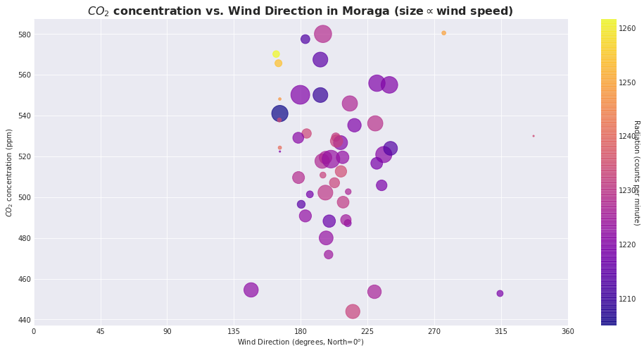

```python
plt.figure(figsize=(17, 8))
plt.scatter(
    moraga_dosenet_and_ws['WindDirection'], moraga_dosenet_and_ws['co2'],
    c=moraga_dosenet_and_ws['radiation'], s=moraga_dosenet_and_ws['WindSpeedGustMPH']*150,
    cmap='plasma', alpha=0.7
)
cbar = plt.colorbar()
cbar.set_label('Radiation (counts per minute)', rotation=270)
plt.xlabel('Wind Direction (degrees, North=$0^o$)')
plt.ylabel('$CO_2$ concentration (ppm)')
plt.xlim(left=0, right=360)
plt.xticks([45 * i for i in range(9)])
plt.title('$CO_2$ concentration vs. Wind Direction in Moraga (size$\propto$wind speed)')
plt.show()
```

From this plot, it seems quite certain there is very weak correlation, if any. But let's do a regression plot to be sure.

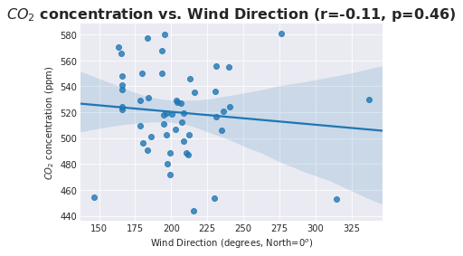

```python
sns.regplot('WindDirection', 'co2', data=moraga_dosenet_and_ws)
plt.xlabel('Wind Direction (degrees, North=$0^o$)')
plt.ylabel('$CO_2$ concentration (ppm)')
r, p = pearsonr(moraga_dosenet_and_ws['co2'], moraga_dosenet_and_ws['WindDirection'])
plt.title(f'$CO_2$ concentration vs. Wind Direction (r={r:.2f}, p={p:.2f})')
None
```

Confirmed. There was no significant correlation between wind direction and $CO_2$ concentration in Moraga.

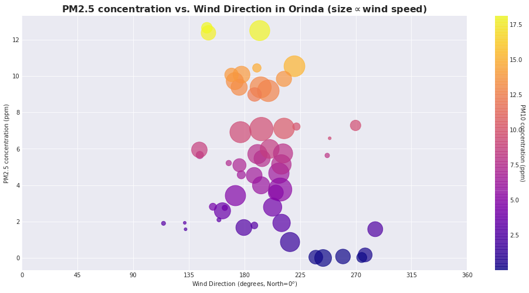

```python
plt.figure(figsize=(17, 8))
plt.scatter(
    orinda_dosenet_and_ws['WindDirection'], orinda_dosenet_and_ws['pm25'],
    c=orinda_dosenet_and_ws['pm10'], s=orinda_dosenet_and_ws['WindSpeedGustMPH']*150,
    cmap='plasma', alpha=0.7
)
cbar = plt.colorbar()
cbar.set_label('PM10 concentration (ppm)', rotation=270)
plt.xlabel('Wind Direction (degrees, North=$0^o$)')
plt.ylabel('PM2.5 concentration (ppm)')
plt.xlim(left=0, right=360)
plt.xticks([45 * i for i in range(9)])
plt.title('PM2.5 concentration vs. Wind Direction in Orinda (size$\propto$wind speed)')
plt.show()
```

This also indicates a lack of correlation between wind direction and airborne particulate matter concentration in Orinda. However, we will look at regression plots to be sure.

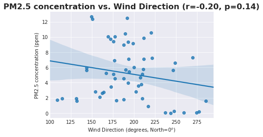

```python
sns.regplot('WindDirection', 'pm25', data=orinda_dosenet_and_ws)
plt.xlabel('Wind Direction (degrees, North=$0^o$)')
plt.ylabel('PM2.5 concentration (ppm)')
r, p = pearsonr(orinda_dosenet_and_ws['pm25'], orinda_dosenet_and_ws['WindDirection'])
plt.title(f'PM2.5 concentration vs. Wind Direction (r={r:.2f}, p={p:.2f})')
None
```

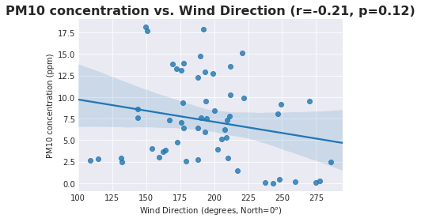

```python
sns.regplot('WindDirection', 'pm10', data=orinda_dosenet_and_ws)
plt.xlabel('Wind Direction (degrees, North=$0^o$)')
plt.ylabel('PM10 concentration (ppm)')
r, p = pearsonr(orinda_dosenet_and_ws['pm10'], orinda_dosenet_and_ws['WindDirection'])
plt.title(f'PM10 concentration vs. Wind Direction (r={r:.2f}, p={p:.2f})')
None
```

There seems to be some correlation between wind direction and particulate matter concentration in Orinda. However, closer analysis of the plots indicates there are some points very close to zero, where the sensor readings are not very reliable, and removing those points will reduce the negative correlation. So overall there is not any significant correlation between wind direction and particulate matter concentration in Orinda.

Finally, in order to make sure that it even makes sense to combine the data from Moraga and Orinda, as we did in the beginning, let's see if both towns get wind blown in from similar directions.

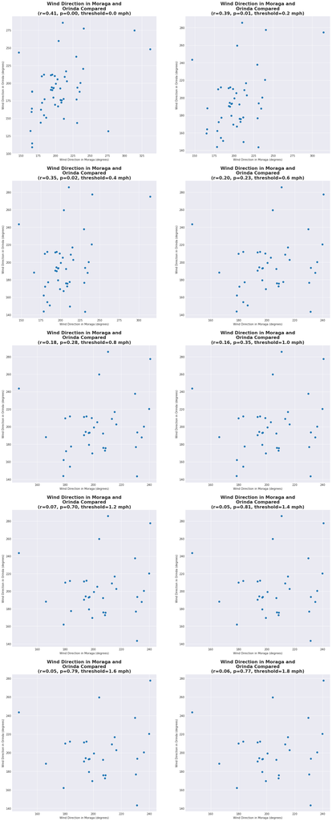

```python
windy = pd.concat([moraga_dosenet_and_ws['WindDirection'], orinda_dosenet_and_ws['WindDirection'],
                   moraga_dosenet_and_ws['WindSpeedGustMPH'], orinda_dosenet_and_ws['WindSpeedGustMPH']],
                  axis=1)


def _filter_by_wind_speed(wind_df, threshold):
    result = wind_df.copy()
    for idx, dir_moraga, dir_orinda, sp_moraga, sp_orinda in wind_df.itertuples():
#         print(idx)
        if sp_moraga < threshold:
            result.iloc[idx-16, 0] = np.nan
        if sp_orinda < threshold:
            result.iloc[idx-16, 1] = np.nan
    return result


fig, axs = plt.subplots(5, 2, figsize=(8, 20), squeeze=False)
fig.subplots_adjust(right=1., left=-1., top=1., bottom=-1.)
for row in range(5):
    for col in range(2):
#         print(windy)
        thres = 0.2 * (2 * row + col)
        windy_ = _filter_by_wind_speed(windy, threshold=thres)
        windy_.dropna(axis=0, how='any', inplace=True)

        axs[row, col].scatter(windy_.iloc[:, 0], windy_.iloc[:, 1])
        axs[row, col].set_xlabel('Wind Direction in Moraga (degrees)')
        axs[row, col].set_ylabel('Wind Direction in Orinda (degrees)')
        r, p = pearsonr(windy_.iloc[:, 0], windy_.iloc[:, 1])
        axs[row, col].set_title(
            f'Wind Direction in Moraga and\nOrinda Compared\n(r={r:.2f}, p={p:.2f}, threshold={thres:.1f} mph)')
None
```